# Hito3_G7_codigo_fuente

*AnimeList*

Integrantes:

- Chritopher Alarcón
- Andy Sandoval

# Indice

1. Introduccion y contexto
2. Preprocesamiento de datos
3. Diccionario
4. Exploracion de datos I
5. Exploracion de datos II
6. Preguntas y problemas
   - 6.1- Problemática 1
   - 6.2- Problemática 2
7. Propuesta metodologica experimental
   - 7.1- Propuesta metodológica experimental 1
   - 7.2- Propuesta metodológica experimental 2
8. Resultados
   - 8.1- Resultados propuesta experimental 1
     - 8.1.1- Preprocesamiento
     - 8.1.2- SVM
     - 8.1.3- K-Means
     - 8.1.4- Conclusion propuesta experimental 1
   - 8.2- Resultados propuesta experimental 2
     - 8.2.1- Preprocesamiento
     - 8.2.2- K-Means
     - 8.2.3- DBSCAN
     - 8.2.4- Evaluacion de clusters
     - 8.2.5- Conclusion propuesta experimental 2
9. Contribuciones

# **Introduccion y contexto**

En los últimos años, el anime ha ido creciendo exponencialmente y ha ido llegando a un público cada vez más grande “Puede que el anime esté atravesando una de sus mejores épocas de la historia. El género tiene audiencias en casi cualquier parte del mundo.” ( Nolan Rada Galindo 9 de junio de 2021 ) , de esto se han dado cuenta muchos servicios de streaming y estudios de televisión, por lo cual, varios quieren aprovechar esta oportunidad para poder atraer a más gente a sintonizar sus servicios y beneficiarse monetariamente “En las últimas décadas hemos vivido un auténtico renacimiento en el mundo del anime con la animación japonesa volviéndose un hobby mucho más normalizado y "mainstream" … Las películas de anime recaudan millones y millones” ( MARILÓ DELGADO 21 Mayo 2022).

Un nuevo estudio de televisión dedicado específicamente a la transmisión de anime, tiene problemas para decidir acerca de qué shows añadir a su transmisión habitual, tienen como objetivo poder captar más público e ir creciendo como estudio alcanzando más rating, fuimos contratados para poder ayudarlos a alcanzar dicho objetivo. Para esto, realizaremos un análisis exploratorio de datos de un dataset histórico que obtuvimos de diversos animes que se han ido estrenando a lo largo de los años, con la finalidad de analizar las variables que nos sirvan y eliminar las que no, ordenar los datos con los que contamos y realizar boxplots y otros tipos de gráficos para examinar y obtener toda la información que podamos del dataset.

Lo que nos motivó a trabajar en conjunto en este estudio fue el querer ayudar a seguir expandiendo la cultura del anime, asistiendo a este estudio de televisión, se logrará que llegue a más televidentes mostrandoles animaciones de calidad, para que se interesen en ellas y sigan de manera autónoma buscando más animes.

# **Preprocesamiento de datos**

```python
#Imports de las librerias a utilizar
import pandas as pd
import numpy as np
import matplotlib.pyplot as plt
import seaborn as sns

#Creacion de un dataframe llamado "data" con el dataset a utilizar
data = pd.read_csv('https://raw.githubusercontent.com/Chris-alr/dataset_datos/main/AnimeList.csv', sep=",")
```

```python
#Revisamos si nuestro dataframe se cargo correctamente
data.loc[1]
```

```
anime_id                                                       2104
title                                              Seto no Hanayome
title_english                                 My Bride is a Mermaid
title_japanese                                                瀬戸の花嫁
title_synonyms                                 The Inland Sea Bride
image_url         https://myanimelist.cdn-dena.com/images/anime/...
type                                                             TV
source                                                        Manga
episodes                                                         26
status                                              Finished Airing
airing                                                        False
aired_string                             Apr 2, 2007 to Oct 1, 2007
aired                    {'from': '2007-04-02', 'to': '2007-10-01'}
duration                                            24 min. per ep.
rating                                    PG-13 - Teens 13 or older
score                                                          7.89
scored_by                                                     91206
rank                                                          727.0
popularity                                                      366
members                                                      204003
favorites                                                      2579
background                                                      NaN
premiered                                               Spring 2007
broadcast                                                   Unknown
related           {'Adaptation': [{'mal_id': 759, 'type': 'manga...
producer                          TV Tokyo, AIC, Square Enix, Sotsu
licensor                                                 Funimation
studio                                                        Gonzo
genre                      Comedy, Parody, Romance, School, Shounen
opening_theme                    ['"Romantic summer" by SUN&LUNAR']
ending_theme      ['#1: "Ashita e no Hikari (明日への光)" by Asuka Hi...
Name: 1, dtype: object
```

# **Diccionario**

- anime_id: identificador del anime
- title: título del anime
- title_english: título del anime en inglés
- title_japanese: título del anime en japonés
- title_synonyms: título del anime con sinonimos
- image_url: dirección url de la imagen de la portada del anime
- type: tipo; puede ser tv, ova, movie.
- source: fuente; puede ser original, manga, music, book
- episodes: cantidad de episodios
- status: si continúa en emisión
- airing: booleano que indica si el anime está en emisión o noaired_string
- aired: fechas de emisión
- duration: duración del anime
- rating: calificación de edad
- score: puntuación
- rank: ranking
- popularity: popularidad
- members: cantidad de seguidores
- favorites: cantidad de favoritos
- producer: productora
- studio: estudio de edición
- genre: géneros
- opening_theme: canción de intro
- ending_theme: canción del final

# **Exploración de datos I**

```python
# Obtenemos las medidas de nuestro dataframe
data.shape
```

```
(14478, 31)
```

```python
data.info()
```

```
<class 'pandas.core.frame.DataFrame'>
RangeIndex: 14478 entries, 0 to 14477
Data columns (total 31 columns):
 #   Column          Non-Null Count  Dtype
---  ------          --------------  -----
 0   anime_id        14478 non-null  int64
 1   title           14478 non-null  object
 2   title_english   5724 non-null   object
 3   title_japanese  14443 non-null  object
 4   title_synonyms  8937 non-null   object
 5   image_url       14382 non-null  object
 6   type            14478 non-null  object
 7   source          14478 non-null  object
 8   episodes        14478 non-null  int64
 9   status          14478 non-null  object
```

[output cut: 23 more lines]

```python
# Mostramos todas las columnas del dataframe, para analizar las que nos son útiles segun nuestro criterio de evaluacion
data.columns.values
```

```
array(['anime_id', 'title', 'title_english', 'title_japanese',
       'title_synonyms', 'image_url', 'type', 'source', 'episodes',
       'status', 'airing', 'aired_string', 'aired', 'duration', 'rating',
       'score', 'scored_by', 'rank', 'popularity', 'members', 'favorites',
       'background', 'premiered', 'broadcast', 'related', 'producer',
       'licensor', 'studio', 'genre', 'opening_theme', 'ending_theme'],
      dtype=object)
```

Creamos algunas nuevas columnas para describir mejor la información que las que actualmente tenemos, por ejemplo, creamos la variable "duration_minutes" para guardar los minutos de cada anime en ves de "duration" y "season" para guardar la estación del año en la que se estreno, en vez "premiered", tambien, separaremos la columna "aired", en dos, "start_year" que como su nombre indica nos muestra el año en el que se comenzo a emitir el anime y "finish_year" que muestra el año en el que se dejo de emitir dicho anime.

```python
data['duration_minutes'] = data['duration'].apply(lambda x : x.split(' ')).apply(lambda x : x[0] if len(x) <= 1 else
        (x[0] if x[1] == 'min.' else
        (int(x[0]) / 60 if x[1] == 'sec.' else
        (int(x[0]) * 60 if x[1] == 'hr.' and len(x) < 3 else
        (int(x[0]) * 60 + int(x[2]) if x[1] == 'hr.' and x[2] != 'per' else
         int(x[0]) * 60  )))))
```

```python
data["premiered"] = data["premiered"].fillna("") # Reemplazar los valores NaN
data['season'] = data['premiered'].apply(lambda x : x.split(" ")[0])
```

```python
data['start_year'] = data['aired'].apply(lambda x : x.split('to')[0]).apply(
                          lambda x : x.split("'")).apply(
                          lambda x : x[3] if len(x) > 1 else x[0] ).apply(
                          lambda x : x.split('-')).apply(
                          lambda x : x[0] if len(x) > 1 else x[0] )
```

```python
data['finish_year'] = data['aired'].apply(lambda x : x.split('to')[1]).apply(
                          lambda x : x.split("'")).apply(
                          lambda x : x[2] if len(x) > 2 else x[0] ).apply(
                          lambda x : x.split('-')[0])
```

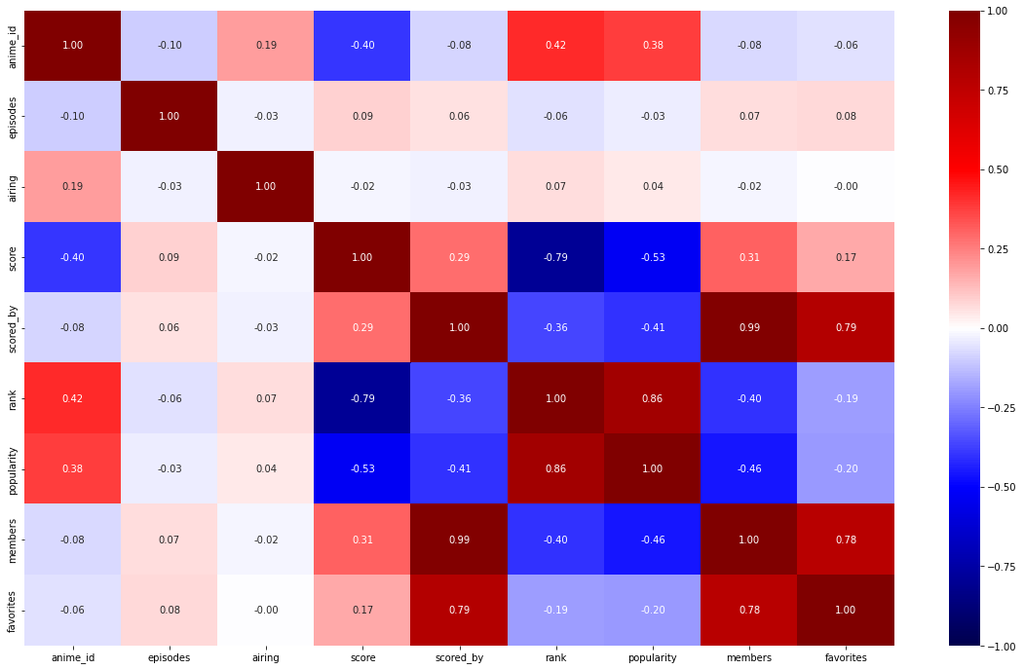

```python
corr_matrix = data.corr()

plt.figure(figsize=(20, 12))
sns.heatmap(corr_matrix, annot=True, vmin=-1, vmax=1, cmap="seismic", fmt=".2f")
plt.gca().patch.set(hatch="X", edgecolor="#666")
plt.show()
```

Como se puede observar en la matriz de correlación, existe una alta correlación entre los atributos:

- Members y Score_by (0.99)

Al haber redundancia entre los atributos nombrados anteriormente, se decide eliminar solamente el atributo Score_by, el cual, no aporta nada a la problemática propuesta.

Según lo analizado y discutido con el equipo, consideramos ciertas columnas del dataset irrelevantes en cuanto a lo que queremos lograr y que no nos aportaran para nuestra investigación, por lo cual, se decidio eliminarlas y centrarnos en las columnas que consideramos relevantes.

```python
animeFiltered=data.drop(columns=['opening_theme', 'ending_theme',  'licensor','related','aired_string','image_url', 'background' , 'title_english' , 'title_japanese' , 'title_synonyms','duration','premiered','aired','broadcast','anime_id','rating','scored_by'])
animeFiltered
```

|  | title | type | source | episodes | status | airing | score | rank | popularity | members | favorites | producer | studio | genre | duration_minutes | season | start_year | finish_year |
| --- | --- | --- | --- | --- | --- | --- | --- | --- | --- | --- | --- | --- | --- | --- | --- | --- | --- | --- |
| 0 | Inu x Boku SS | TV | Manga | 12 | Finished Airing | False | 7.63 | 1274.0 | 231 | 283882 | 2809 | Aniplex, Square Enix, Mainichi Broadcasting Sy... | David Production | Comedy, Supernatural, Romance, Shounen | 24 | Winter | 2012 | 2012 |
| 1 | Seto no Hanayome | TV | Manga | 26 | Finished Airing | False | 7.89 | 727.0 | 366 | 204003 | 2579 | TV Tokyo, AIC, Square Enix, Sotsu | Gonzo | Comedy, Parody, Romance, School, Shounen | 24 | Spring | 2007 | 2007 |
| 2 | Shugo Chara!! Doki | TV | Manga | 51 | Finished Airing | False | 7.55 | 1508.0 | 1173 | 70127 | 802 | TV Tokyo, Sotsu | Satelight | Comedy, Magic, School, Shoujo | 24 | Fall | 2008 | 2009 |
| 3 | Princess Tutu | TV | Original | 38 | Finished Airing | False | 8.21 | 307.0 | 916 | 93312 | 3344 | Memory-Tech, GANSIS, Marvelous AQL | Hal Film Maker | Comedy, Drama, Magic, Romance, Fantasy | 16 | Summer | 2002 | 2003 |
| 4 | Bakuman. 3rd Season | TV | Manga | 25 | Finished Airing | False | 8.67 | 50.0 | 426 | 182765 | 2082 | NHK, Shueisha | J.C.Staff | Comedy, Drama, Romance, Shounen | 24 | Fall | 2012 | 2013 |
| ... | ... | ... | ... | ... | ... | ... | ... | ... | ... | ... | ... | ... | ... | ... | ... | ... | ... | ... |
| 14473 | Gutchonpa Omoshiro Hanashi | TV | Unknown | 5 | Finished Airing | False | 5.50 | 10337.0 | 13598 | 76 | 0 | NaN | NaN | Kids | 8 | Fall | 1987 | 1988 |
| 14474 | Geba Geba Shou Time! | OVA | Unknown | 1 | Finished Airing | False | 4.60 | 10236.0 | 13284 | 90 | 0 | Studio Lotus | NaN | Comedy | 25 |  | 1986 | 1986 |
| 14475 | Godzilla: Hoshi wo Kuu Mono | Movie | Other | 1 | Not yet aired | False | 0.00 | NaN | 7226 | 1741 | 0 | NaN | NaN | Action, Sci-Fi, Adventure, Fantasy | Unknown |  |  |  |
| 14476 | Nippon Mukashibanashi: Sannen Netarou | OVA | Other | 1 | Finished Airing | False | 6.00 | 11557.0 | 14334 | 32 | 0 | NaN | NaN | Fantasy, Kids | 40 |  |  |  |
| 14477 | Senjou no Valkyria Special | Special | Unknown | 1 | Finished Airing | False | 5.15 | 12056.0 | 9767 | 476 | 0 | NaN | A-1 Pictures | Comedy | 3 |  | 2010 | 2010 |

14478 rows × 18 columns

Cabe recalcar, que se eliminaron las columnas que bajo nuestro criterio no eran de interes en esta investigación, asi como tambien, algunas que repetian información, como por ejemplo "aired_string" y "aired", y dividimos "aired" en "start_year" y "finish_year" como se explico anteriormente.

Eliminaremos las filas cuyo "score" sea 0 ya que se asume que es un anime nuevo y no posee valoraciones, o que aquellos que votaron eran muy pocos para considerar, calificando asi con el puntaje minimo.

```python
animeFilteredByScore = animeFiltered[animeFiltered['score'] == 0].index
animeFiltered.drop(animeFilteredByScore , inplace = True)
animeFiltered
```

|  | title | type | source | episodes | status | airing | score | rank | popularity | members | favorites | producer | studio | genre | duration_minutes | season | start_year | finish_year |
| --- | --- | --- | --- | --- | --- | --- | --- | --- | --- | --- | --- | --- | --- | --- | --- | --- | --- | --- |
| 0 | Inu x Boku SS | TV | Manga | 12 | Finished Airing | False | 7.63 | 1274.0 | 231 | 283882 | 2809 | Aniplex, Square Enix, Mainichi Broadcasting Sy... | David Production | Comedy, Supernatural, Romance, Shounen | 24 | Winter | 2012 | 2012 |
| 1 | Seto no Hanayome | TV | Manga | 26 | Finished Airing | False | 7.89 | 727.0 | 366 | 204003 | 2579 | TV Tokyo, AIC, Square Enix, Sotsu | Gonzo | Comedy, Parody, Romance, School, Shounen | 24 | Spring | 2007 | 2007 |
| 2 | Shugo Chara!! Doki | TV | Manga | 51 | Finished Airing | False | 7.55 | 1508.0 | 1173 | 70127 | 802 | TV Tokyo, Sotsu | Satelight | Comedy, Magic, School, Shoujo | 24 | Fall | 2008 | 2009 |
| 3 | Princess Tutu | TV | Original | 38 | Finished Airing | False | 8.21 | 307.0 | 916 | 93312 | 3344 | Memory-Tech, GANSIS, Marvelous AQL | Hal Film Maker | Comedy, Drama, Magic, Romance, Fantasy | 16 | Summer | 2002 | 2003 |
| 4 | Bakuman. 3rd Season | TV | Manga | 25 | Finished Airing | False | 8.67 | 50.0 | 426 | 182765 | 2082 | NHK, Shueisha | J.C.Staff | Comedy, Drama, Romance, Shounen | 24 | Fall | 2012 | 2013 |
| ... | ... | ... | ... | ... | ... | ... | ... | ... | ... | ... | ... | ... | ... | ... | ... | ... | ... | ... |
| 14472 | Minna no Taabou Konnichiwa | OVA | Original | 1 | Finished Airing | False | 6.75 | 11329.0 | 14204 | 40 | 0 | Sanrio | NaN | Kids | 20 |  |  |  |
| 14473 | Gutchonpa Omoshiro Hanashi | TV | Unknown | 5 | Finished Airing | False | 5.50 | 10337.0 | 13598 | 76 | 0 | NaN | NaN | Kids | 8 | Fall | 1987 | 1988 |
| 14474 | Geba Geba Shou Time! | OVA | Unknown | 1 | Finished Airing | False | 4.60 | 10236.0 | 13284 | 90 | 0 | Studio Lotus | NaN | Comedy | 25 |  | 1986 | 1986 |
| 14476 | Nippon Mukashibanashi: Sannen Netarou | OVA | Other | 1 | Finished Airing | False | 6.00 | 11557.0 | 14334 | 32 | 0 | NaN | NaN | Fantasy, Kids | 40 |  |  |  |
| 14477 | Senjou no Valkyria Special | Special | Unknown | 1 | Finished Airing | False | 5.15 | 12056.0 | 9767 | 476 | 0 | NaN | A-1 Pictures | Comedy | 3 |  | 2010 | 2010 |

14124 rows × 18 columns

```python
#Obtenemos la medida de nuestro dataframe luego de la eliminación de columnas
animeFiltered.shape
```

```
(14124, 18)
```

```python
# Revisamos los datos una vez mas para ver los tipos de datos que hay y si son correctos (es decir que corresponden a sus columnas)
animeFiltered.info()
```

```
<class 'pandas.core.frame.DataFrame'>
Int64Index: 14124 entries, 0 to 14477
Data columns (total 18 columns):
 #   Column            Non-Null Count  Dtype
---  ------            --------------  -----
 0   title             14124 non-null  object
 1   type              14124 non-null  object
 2   source            14124 non-null  object
 3   episodes          14124 non-null  int64
 4   status            14124 non-null  object
 5   airing            14124 non-null  bool
 6   score             14124 non-null  float64
 7   rank              12880 non-null  float64
 8   popularity        14124 non-null  int64
 9   members           14124 non-null  int64
 10  favorites         14124 non-null  int64
 11  producer          8221 non-null   object
 12  studio            8381 non-null   object
 13  genre             14068 non-null  object
 14  duration_minutes  14124 non-null  object
 15  season            14124 non-null  object
 16  start_year        14124 non-null  object
 17  finish_year       14124 non-null  object
dtypes: bool(1), float64(2), int64(4), object(11)
memory usage: 2.0+ MB
```

Cambiamos los tipos de datos que se encuentran como "object" a los que corresponden, por ejemplo, en la columna "duration_minutes"

```python
# Tratamos los valores unknown, reemplazandolos por valores null
animeFiltered['duration_minutes'] = animeFiltered['duration_minutes'].replace('Unknown' , np.nan)
animeFiltered['start_year'] = animeFiltered['start_year'].replace('' ,'9999999' )
animeFiltered['finish_year'] = animeFiltered['finish_year'].replace('' ,'9999999' )
animeFiltered['season'] = animeFiltered['season'].replace('' ,pd.NA )
animeFiltered['type'] = animeFiltered['type'].replace('Unknown' , pd.NA)
animeFiltered['source'] = animeFiltered['source'].replace('Unknown' , pd.NA)
```

```python
# Convertimos la columna "duration_minutes" en valores de tipo float
animeFiltered['duration_minutes'] = animeFiltered['duration_minutes'].astype('float')
animeFiltered['start_year'] = animeFiltered['start_year'].astype('int')
animeFiltered['finish_year'] = animeFiltered['finish_year'].astype('int')
```

```python
# Reemplazamos los valores colocados con 9999999 (para identificarlos como nulos) por nulos con pd.NA
animeFiltered['start_year'] = animeFiltered['start_year'].replace('9999999' , pd.NA )
animeFiltered['finish_year'] = animeFiltered['finish_year'].replace('9999999' , pd.NA )
animeFiltered
```

|  | title | type | source | episodes | status | airing | score | rank | popularity | members | favorites | producer | studio | genre | duration_minutes | season | start_year | finish_year |
| --- | --- | --- | --- | --- | --- | --- | --- | --- | --- | --- | --- | --- | --- | --- | --- | --- | --- | --- |
| 0 | Inu x Boku SS | TV | Manga | 12 | Finished Airing | False | 7.63 | 1274.0 | 231 | 283882 | 2809 | Aniplex, Square Enix, Mainichi Broadcasting Sy... | David Production | Comedy, Supernatural, Romance, Shounen | 24.0 | Winter | 2012 | 2012 |
| 1 | Seto no Hanayome | TV | Manga | 26 | Finished Airing | False | 7.89 | 727.0 | 366 | 204003 | 2579 | TV Tokyo, AIC, Square Enix, Sotsu | Gonzo | Comedy, Parody, Romance, School, Shounen | 24.0 | Spring | 2007 | 2007 |
| 2 | Shugo Chara!! Doki | TV | Manga | 51 | Finished Airing | False | 7.55 | 1508.0 | 1173 | 70127 | 802 | TV Tokyo, Sotsu | Satelight | Comedy, Magic, School, Shoujo | 24.0 | Fall | 2008 | 2009 |
| 3 | Princess Tutu | TV | Original | 38 | Finished Airing | False | 8.21 | 307.0 | 916 | 93312 | 3344 | Memory-Tech, GANSIS, Marvelous AQL | Hal Film Maker | Comedy, Drama, Magic, Romance, Fantasy | 16.0 | Summer | 2002 | 2003 |
| 4 | Bakuman. 3rd Season | TV | Manga | 25 | Finished Airing | False | 8.67 | 50.0 | 426 | 182765 | 2082 | NHK, Shueisha | J.C.Staff | Comedy, Drama, Romance, Shounen | 24.0 | Fall | 2012 | 2013 |
| ... | ... | ... | ... | ... | ... | ... | ... | ... | ... | ... | ... | ... | ... | ... | ... | ... | ... | ... |
| 14472 | Minna no Taabou Konnichiwa | OVA | Original | 1 | Finished Airing | False | 6.75 | 11329.0 | 14204 | 40 | 0 | Sanrio | NaN | Kids | 20.0 | <NA> | 9999999 | 9999999 |
| 14473 | Gutchonpa Omoshiro Hanashi | TV | <NA> | 5 | Finished Airing | False | 5.50 | 10337.0 | 13598 | 76 | 0 | NaN | NaN | Kids | 8.0 | Fall | 1987 | 1988 |
| 14474 | Geba Geba Shou Time! | OVA | <NA> | 1 | Finished Airing | False | 4.60 | 10236.0 | 13284 | 90 | 0 | Studio Lotus | NaN | Comedy | 25.0 | <NA> | 1986 | 1986 |
| 14476 | Nippon Mukashibanashi: Sannen Netarou | OVA | Other | 1 | Finished Airing | False | 6.00 | 11557.0 | 14334 | 32 | 0 | NaN | NaN | Fantasy, Kids | 40.0 | <NA> | 9999999 | 9999999 |
| 14477 | Senjou no Valkyria Special | Special | <NA> | 1 | Finished Airing | False | 5.15 | 12056.0 | 9767 | 476 | 0 | NaN | A-1 Pictures | Comedy | 3.0 | <NA> | 2010 | 2010 |

14124 rows × 18 columns

```python
# Mostramos la info para corroborar que se hayan cambiado los tipos de datos
animeFiltered.info()
```

```
<class 'pandas.core.frame.DataFrame'>
Int64Index: 14124 entries, 0 to 14477
Data columns (total 18 columns):
 #   Column            Non-Null Count  Dtype
---  ------            --------------  -----
 0   title             14124 non-null  object
 1   type              14124 non-null  object
 2   source            9927 non-null   object
 3   episodes          14124 non-null  int64
 4   status            14124 non-null  object
 5   airing            14124 non-null  bool
 6   score             14124 non-null  float64
 7   rank              12880 non-null  float64
 8   popularity        14124 non-null  int64
 9   members           14124 non-null  int64
 10  favorites         14124 non-null  int64
 11  producer          8221 non-null   object
 12  studio            8381 non-null   object
 13  genre             14068 non-null  object
 14  duration_minutes  13991 non-null  float64
 15  season            4021 non-null   object
 16  start_year        14124 non-null  int64
 17  finish_year       14124 non-null  int64
dtypes: bool(1), float64(3), int64(6), object(8)
memory usage: 2.0+ MB
```

```python
animeFiltered.head(10)
```

|  | title | type | source | episodes | status | airing | score | rank | popularity | members | favorites | producer | studio | genre | duration_minutes | season | start_year | finish_year |
| --- | --- | --- | --- | --- | --- | --- | --- | --- | --- | --- | --- | --- | --- | --- | --- | --- | --- | --- |
| 0 | Inu x Boku SS | TV | Manga | 12 | Finished Airing | False | 7.63 | 1274.0 | 231 | 283882 | 2809 | Aniplex, Square Enix, Mainichi Broadcasting Sy... | David Production | Comedy, Supernatural, Romance, Shounen | 24.0 | Winter | 2012 | 2012 |
| 1 | Seto no Hanayome | TV | Manga | 26 | Finished Airing | False | 7.89 | 727.0 | 366 | 204003 | 2579 | TV Tokyo, AIC, Square Enix, Sotsu | Gonzo | Comedy, Parody, Romance, School, Shounen | 24.0 | Spring | 2007 | 2007 |
| 2 | Shugo Chara!! Doki | TV | Manga | 51 | Finished Airing | False | 7.55 | 1508.0 | 1173 | 70127 | 802 | TV Tokyo, Sotsu | Satelight | Comedy, Magic, School, Shoujo | 24.0 | Fall | 2008 | 2009 |
| 3 | Princess Tutu | TV | Original | 38 | Finished Airing | False | 8.21 | 307.0 | 916 | 93312 | 3344 | Memory-Tech, GANSIS, Marvelous AQL | Hal Film Maker | Comedy, Drama, Magic, Romance, Fantasy | 16.0 | Summer | 2002 | 2003 |
| 4 | Bakuman. 3rd Season | TV | Manga | 25 | Finished Airing | False | 8.67 | 50.0 | 426 | 182765 | 2082 | NHK, Shueisha | J.C.Staff | Comedy, Drama, Romance, Shounen | 24.0 | Fall | 2012 | 2013 |
| 5 | Yume-iro Pâtissière | TV | Manga | 50 | Finished Airing | False | 8.03 | 526.0 | 1630 | 45625 | 826 | Yomiuri Telecasting, DAX Production, Shueisha | Studio Pierrot, Studio Hibari | Kids, School, Shoujo | 24.0 | Fall | 2009 | 2010 |
| 6 | Ultra Maniac | TV | Manga | 26 | Finished Airing | False | 7.26 | 2594.0 | 2490 | 22778 | 122 | WAO World, Studio Jack | Production Reed | Magic, Comedy, Romance, School, Shoujo | 24.0 | Spring | 2003 | 2003 |
| 7 | Shakugan no Shana II (Second) | TV | Light novel | 24 | Finished Airing | False | 7.72 | 1066.0 | 332 | 220591 | 1075 | Geneon Universal Entertainment, ASCII Media Works | J.C.Staff | Action, Drama, Fantasy, Romance, School, Super... | 24.0 | Fall | 2007 | 2008 |
| 8 | Nodame Cantabile: Paris-hen | TV | Manga | 11 | Finished Airing | False | 8.24 | 281.0 | 988 | 85660 | 282 | Fuji TV, Asmik Ace Entertainment, Sony Music E... | J.C.Staff | Music, Slice of Life, Comedy, Romance, Josei | 23.0 | Fall | 2008 | 2008 |
| 9 | Ouran Koukou Host Club | TV | Manga | 26 | Finished Airing | False | 8.34 | 205.0 | 69 | 538843 | 24072 | VAP, Hakusensha, Nippon Television Network | Bones | Comedy, Harem, Romance, School, Shoujo | 23.0 | Spring | 2006 | 2006 |

En nuestro dataset, existen animes que no poseen genero, por ende optaremos por dividirla.

```python
animeFiltered["genre"].unique
```

```
<bound method Series.unique of 0          Comedy, Supernatural, Romance, Shounen
1        Comedy, Parody, Romance, School, Shounen
2                   Comedy, Magic, School, Shoujo
3          Comedy, Drama, Magic, Romance, Fantasy
4                 Comedy, Drama, Romance, Shounen
                           ...
14472                                        Kids
14473                                        Kids
14474                                      Comedy
14476                               Fantasy, Kids
14477                                      Comedy
Name: genre, Length: 14124, dtype: object>
```

# **Exploración de datos II**

Primero, veremos la distribución de la variable "score", ya que, la puntuación es una característica relevante a la hora de andar en busca de algún anime, siendo más atractivas las que poseen una puntuación alta o sobre lo normal.

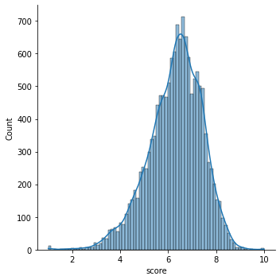

```python
sns.displot(data = animeFiltered , x = 'score' , kde = True)
```

Posteriormente, se desea conocer el top 10 de los géneros que más existen dentro de los animes. Como la columna "genre" presenta mayormente más de 1 género, con el siguiente código obtendremos los géneros de forma individual para obtener la cantidad de cada uno, primero quitamos los espacios y separamos por coma, posteriormente usaremos la función mencionada anterior y procederemos a mostrar los primeros 10 géneros que están presentes en los animes.

```python
def to_1D(series):
 return pd.Series([x for _list in series for x in _list])
```

```python
animeFiltered['Genres_Split'] = [str(x).replace(' ','') for x in animeFiltered['genre']]
animeFiltered['Genres_Split'] = [str(x).split(',') for x in animeFiltered['Genres_Split']]

genres  = to_1D(animeFiltered['Genres_Split']).value_counts()
genres.head(10)
```

```
Comedy         5141
Action         3114
Fantasy        2619
Adventure      2521
Drama          2227
Sci-Fi         2207
Kids           1988
Shounen        1732
Romance        1597
SliceofLife    1485
dtype: int64
```

Lo visualizaremos de mejor manera en el gráfico siguiente:

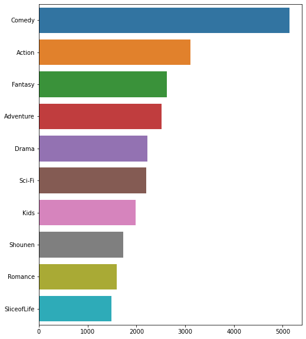

```python
name_columnas_genres_top10 = to_1D(animeFiltered['Genres_Split']).value_counts().head(10).index

plt.figure(figsize=(8,10))

sns.barplot(y = name_columnas_genres_top10 , x = genres.head(10) )
```

Con el gráfico presente podemos observar los 10 géneros que más se presentan en los animes, siendo así el género de "Comedy" el que más está presente con 5141 animes, lo sigue el "Action" y "Fantasy", entre otros.

Ahora, queremos conocer el top 10 de los productores de los animes, se entiende que por productor es la empresa que financia el respectivo anime.

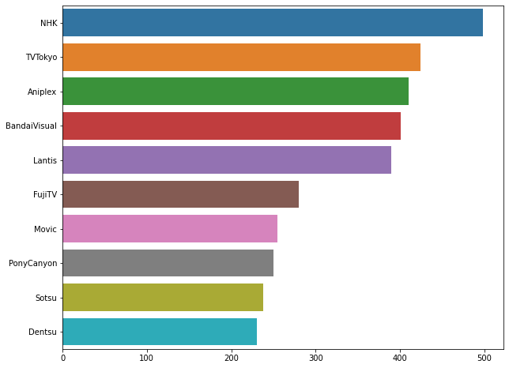

```python
animeFiltered['Producers_Split'] = [str(x).replace(' ','') for x in animeFiltered['producer']]
animeFiltered['Producers_Split'] = [str(x).split(',') for x in animeFiltered['Producers_Split']]

producer_top10 = to_1D(animeFiltered['Producers_Split']).value_counts()[1:11].index
nproducer_top10  = to_1D(animeFiltered['Producers_Split']).value_counts()[1:11]

plt.figure(figsize=(10,8))
sns.barplot(y = producer_top10 , x = nproducer_top10 )
```

Se puede observar que la productora NHK lidera en el top 10.

```python
del(animeFiltered['producer'])
animeFiltered
```

|  | title | type | source | episodes | status | airing | score | rank | popularity | members | favorites | studio | genre | duration_minutes | season | start_year | finish_year | Genres_Split | Producers_Split |
| --- | --- | --- | --- | --- | --- | --- | --- | --- | --- | --- | --- | --- | --- | --- | --- | --- | --- | --- | --- |
| 0 | Inu x Boku SS | TV | Manga | 12 | Finished Airing | False | 7.63 | 1274.0 | 231 | 283882 | 2809 | David Production | Comedy, Supernatural, Romance, Shounen | 24.0 | Winter | 2012 | 2012 | [Comedy, Supernatural, Romance, Shounen] | [Aniplex, SquareEnix, MainichiBroadcastingSyst... |
| 1 | Seto no Hanayome | TV | Manga | 26 | Finished Airing | False | 7.89 | 727.0 | 366 | 204003 | 2579 | Gonzo | Comedy, Parody, Romance, School, Shounen | 24.0 | Spring | 2007 | 2007 | [Comedy, Parody, Romance, School, Shounen] | [TVTokyo, AIC, SquareEnix, Sotsu] |
| 2 | Shugo Chara!! Doki | TV | Manga | 51 | Finished Airing | False | 7.55 | 1508.0 | 1173 | 70127 | 802 | Satelight | Comedy, Magic, School, Shoujo | 24.0 | Fall | 2008 | 2009 | [Comedy, Magic, School, Shoujo] | [TVTokyo, Sotsu] |
| 3 | Princess Tutu | TV | Original | 38 | Finished Airing | False | 8.21 | 307.0 | 916 | 93312 | 3344 | Hal Film Maker | Comedy, Drama, Magic, Romance, Fantasy | 16.0 | Summer | 2002 | 2003 | [Comedy, Drama, Magic, Romance, Fantasy] | [Memory-Tech, GANSIS, MarvelousAQL] |
| 4 | Bakuman. 3rd Season | TV | Manga | 25 | Finished Airing | False | 8.67 | 50.0 | 426 | 182765 | 2082 | J.C.Staff | Comedy, Drama, Romance, Shounen | 24.0 | Fall | 2012 | 2013 | [Comedy, Drama, Romance, Shounen] | [NHK, Shueisha] |
| ... | ... | ... | ... | ... | ... | ... | ... | ... | ... | ... | ... | ... | ... | ... | ... | ... | ... | ... | ... |
| 14472 | Minna no Taabou Konnichiwa | OVA | Original | 1 | Finished Airing | False | 6.75 | 11329.0 | 14204 | 40 | 0 | NaN | Kids | 20.0 | <NA> | 9999999 | 9999999 | [Kids] | [Sanrio] |
| 14473 | Gutchonpa Omoshiro Hanashi | TV | <NA> | 5 | Finished Airing | False | 5.50 | 10337.0 | 13598 | 76 | 0 | NaN | Kids | 8.0 | Fall | 1987 | 1988 | [Kids] | [nan] |
| 14474 | Geba Geba Shou Time! | OVA | <NA> | 1 | Finished Airing | False | 4.60 | 10236.0 | 13284 | 90 | 0 | NaN | Comedy | 25.0 | <NA> | 1986 | 1986 | [Comedy] | [StudioLotus] |
| 14476 | Nippon Mukashibanashi: Sannen Netarou | OVA | Other | 1 | Finished Airing | False | 6.00 | 11557.0 | 14334 | 32 | 0 | NaN | Fantasy, Kids | 40.0 | <NA> | 9999999 | 9999999 | [Fantasy, Kids] | [nan] |
| 14477 | Senjou no Valkyria Special | Special | <NA> | 1 | Finished Airing | False | 5.15 | 12056.0 | 9767 | 476 | 0 | A-1 Pictures | Comedy | 3.0 | <NA> | 2010 | 2010 | [Comedy] | [nan] |

14124 rows × 19 columns

**Puntuación vs Episodios**

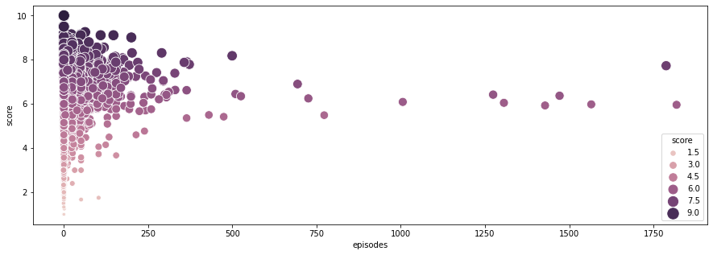

```python
plt.figure(figsize=(15,5))
sns.scatterplot(data = animeFiltered , x = 'episodes' , y= 'score' , hue = 'score' , size = 'score' , sizes = (20,200))
```

Con el gráfico anterior podemos observar que la cantidad de episodios no influye en la puntuación que tenga el respectivo anime, este puede tener menos de 24 episodios y tener buena valoración o tener casi 200 episodios y tener una valoración baja.

**Puntuación vs Duración en minutos**

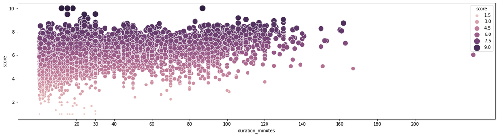

```python
plt.figure(figsize=(20,5))
plt.xticks([20,30,40,60,80,100,120,140,160,180,200])
sns.scatterplot(data = animeFiltered , x = 'duration_minutes' , y= 'score' , hue = 'score' , size = 'score', sizes = (20,200))
```

# **Preguntas**

### Problemática 1

El primer problema de clasificación a abordar es el de clasificar la puntuación del anime tomando en cuenta que si el anime está en emisión o no. Para abordar este problema, hemos decidido aplicar el modelo de clasificación 'SVM' y 'K-means'. La razón de por qué la utilización de estos modelos, es debido a que se compararon en base a las métricas vistas en clases, poniendo especial énfasis en Recall, pues nos interesa conocer qué tan determinante es el estado de emisión de un anime en su puntuación.

### Problemática 2

Nuestra segunda problematica consta en encontrar grupos de anime basandonos en algunas variables del dataset y comparandolas con el score para ver su influencia (score: puntuacion del anime)

Utilizaremos K-means y DBSCAN para encontrar grupos de anime con scores en comun.

# **Propuesta metodológica experimental**

### Propuesta metodológica experimental problemática 1

Para dar respuesta a la pregunta enfocada a la clasificación de las puntuaciones de anime en función de que si se encuentra en emisión o no, se implementará un modelo de clasificación supervisada, que es la Support Vector Machine (SVM) elegida para esta tarea y se implementará el algoritmo K-Means. Se comparan las medidas vistas en clase, con especial énfasis en el Recall.

### Propuesta metodológica experimental problemática 2

Para responder la problematica numero 2, utilizaremos el método del codo o Elbow Method para determinar el numero optimo de clusters a utilizar en cada caso, e implementaremos dos algoritmos de clustering para las pruebas (K-Means y DBSCAN)

- También probaremos usando dos subconjuntos de atributos al hacer clustering para evaluar si los ejemplos se agrupan de manera distinta cuando consideramos información diferente.
- Para evaluar los clusters, utilizaremos el enfoque visual así como la Matriz de Similitud para evaluar por proximidad.

# Resultados

## **Resultados propuesta experimental 1**

### Preprocesamiento

Para empezar, debemos transformar nuestros datos a binario debido a que para hacer uso de los algoritmos de agrupación deben ser del mismo tipo. El atributo score tendra la siguiente regla:

- Score [0 - 3]: Puntuación mala : 0
- Score ]3 - 7]: Puntuación regular : 1
- Score ]7 - 10]: Puntuación buena : 2

En cambio, el atributo Airing seguira la siguiente regla:

- False: 0
- True: 1

Obteniendo inicialmente que los atributos sigan sus respectivas reglas, procederemos a utilizar el algoritmo SVM y KMeans.

```python
animeSVM = animeFiltered.drop(columns=['type','title','source','status','studio','episodes','genre','season','Genres_Split','Producers_Split','start_year','finish_year','rank',	'popularity','members',	'favorites',	'duration_minutes'])
animeSVM.head()
```

|  | airing | score |
| --- | --- | --- |
| 0 | False | 7.63 |
| 1 | False | 7.89 |
| 2 | False | 7.55 |
| 3 | False | 8.21 |
| 4 | False | 8.67 |

```python
airing = {True : 1, False : 0}
animeSVM['airing'] = animeSVM['airing'].map(airing)
animeSVM['airing'].value_counts().head()
```

```
0    13779
1      345
Name: airing, dtype: int64
```

```python
condition = [(animeSVM['score'] <= 3),((animeSVM['score'] > 3) & (animeSVM['score'] <= 7)), ((animeSVM['score'] > 7) & (animeSVM['score'] <= 10)),]
values = [0,1,2]
animeSVM['score'] = np.select(condition, values)

animeSVM['score'].value_counts().head()
```

```
1    10168
2     3873
0       83
Name: score, dtype: int64
```

### SVM

Posterior a la transformación de datos, importamos las librerias a utilizar

```python
from sklearn.svm import SVC, LinearSVC
from sklearn.model_selection import train_test_split
from sklearn.metrics import classification_report
```

```python
sample = animeSVM
y_sample = sample["score"]
X_sample = sample.drop("airing", axis=1)

X_train, X_validate, y_train, y_validate = train_test_split(X_sample, y_sample, random_state=42)

print(X_train.shape, y_train.shape)
print(X_validate.shape, y_validate.shape)
```

```
(10593, 1) (10593,)
(3531, 1) (3531,)
```

```python
modelo_SVM = LinearSVC(random_state=0, tol=1e-5, max_iter=1000)
modelo_entrenado_SVM = modelo_SVM.fit(X_train,y_train)
y_pred = modelo_SVM.predict(X_validate)

print("Predicción")
print(classification_report(y_train, modelo_SVM.predict(X_train)))
print("Validación")
print(classification_report(y_validate, y_pred))
```

```
Predicción
              precision    recall  f1-score   support

           0       0.00      0.00      0.00        64
           1       0.99      1.00      1.00      7620
           2       1.00      1.00      1.00      2909

    accuracy                           0.99     10593
   macro avg       0.66      0.67      0.67     10593
weighted avg       0.99      0.99      0.99     10593

Validación
              precision    recall  f1-score   support

           0       0.00      0.00      0.00        19
           1       0.99      1.00      1.00      2548
           2       1.00      1.00      1.00       964

    accuracy                           0.99      3531
   macro avg       0.66      0.67      0.67      3531
weighted avg       0.99      0.99      0.99      3531
```

Podemos observar, respecto a la precisión, que el modelo tiene un 100% de probabilidad de acertar cuando da como resultado de la clasificación del score es Buena y un 99% para el score Regular, sin embargo, es 0% en el score Malo. Por otra parte, respecto al recall, vemos que fue capaz de clasificar el 100% de los datos en el score Bueno y Regular, no asi, en el score Malo. Respecto al f1-score, al igual que el recall en el score Bueno y Regular es de un 100% y en el score Malo de un 0%. Finalmente, en cuanto al accuracy, el modelo fue capaz de predecir de forma correcta el 99% de los datos.

### K-MEANS

```python
animeKM = animeSVM
animeKM = animeKM[animeKM['airing'] == 0]
X = pd.DataFrame(animeKM).to_numpy()
X
```

```
array([[0, 2],
       [0, 2],
       [0, 2],
       ...,
       [0, 1],
       [0, 1],
       [0, 1]])
```

```python
animeKM2 = animeSVM
animeKM2 = animeKM2[(animeKM2['score'] == 1) | (animeKM2['score'] == 2)]
Y = pd.DataFrame(animeKM2).to_numpy()
Y
```

```
array([[0, 2],
       [0, 2],
       [0, 2],
       ...,
       [0, 1],
       [0, 1],
       [0, 1]])
```

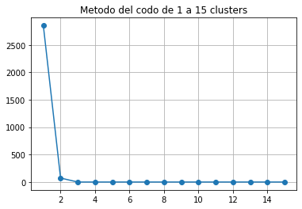

```python
from sklearn.cluster import KMeans
import matplotlib.pyplot as plt

sse=[]

clusters=list(range(1,16))
for k in clusters:
    kmeans = KMeans(n_clusters=k).fit(X)
    sse.append(kmeans.inertia_)

plt.plot(clusters, sse, marker="o")
plt.title("Metodo del codo de 1 a 15 clusters")
plt.grid(True)
plt.show()
```

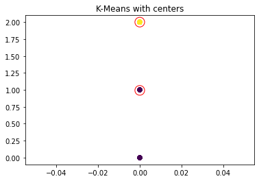

```python
kmeans = KMeans(n_clusters=2, random_state=50).fit(X)
centers = kmeans.cluster_centers_

plt.scatter(X[:, 0], X[:, 1], c=kmeans.labels_)
plt.scatter(centers[:,0], centers[:,1], s=200, facecolors='none', edgecolors='r')
plt.title("K-Means with centers")
plt.show()
```

Podemos observar el resultado del algoritmo de K-Means el cual falla, debido a que este algoritmo posee algunas desventajas, como la elección del k, nosotros decidimos cual usar y la posibilidad de que se cometa un error es bastante alta, igualmente este algoritmo es muy sensible a los outliers, los casos extremos hacen que el cluster se vea muy afectado.

### Conclusión propuesta experimental 1

Luego de realizar los métodos de clustering con los datos, nos podemos percatar que el algoritmo SVM responde de mejor manera que el K-Means, este último presenta fallas. Debido a esto, nos quedaremos con los resultados del SVM, además de que sus resultados son demasiado precisos haciendo uso de todos los datos.

## **Resultados propuesta experimental 2**

### Preprocesamiento

El estudio de television que nos contrato, nos solicito que filtraramos los animes para que no trabajaramos con animes que tuvieran mas de 500 episodios, ni duraran mas de 60 minutos, por lo cual, filtraremos antes de trabajar.

```python
animeKmeans = animeFiltered.drop(columns=['type','title','source','status','airing','studio','genre','season','Genres_Split','Producers_Split','start_year','finish_year','rank',	'popularity','members',	'favorites',	'duration_minutes'])
animeKmeans = animeKmeans[animeKmeans['episodes'].notna()]# Filtramos los episodios para que no sean nulos
animeKmeans = animeKmeans[animeKmeans['episodes'] > 0] # Filtramos los episodios para que sean mayores a 0
animeKmeans = animeKmeans[animeKmeans['episodes'] <= 500]# Filtramos los episodios para que sean menores o iguales a 500
animeKmeans.head()
```

|  | episodes | score |
| --- | --- | --- |
| 0 | 12 | 7.63 |
| 1 | 26 | 7.89 |
| 2 | 51 | 7.55 |
| 3 | 38 | 8.21 |
| 4 | 25 | 8.67 |

```python
animeKmeans2 = animeFiltered.drop(columns=['type','title','source','status','airing','studio','genre','season','Genres_Split','Producers_Split','start_year','finish_year','rank',	'popularity','members',	'favorites',	'episodes'])
animeKmeans2 = animeKmeans2[animeKmeans2['duration_minutes'].notna()]# Filtramos los valores nulos
animeKmeans2 = animeKmeans2[animeKmeans2['duration_minutes'] <= 60]# Filtramos los valores para que su duracion en minutos sea menor o igual a 60
animeKmeans2.head()
```

|  | score | duration_minutes |
| --- | --- | --- |
| 0 | 7.63 | 24.0 |
| 1 | 7.89 | 24.0 |
| 2 | 7.55 | 24.0 |
| 3 | 8.21 | 16.0 |
| 4 | 8.67 | 24.0 |

```python
X = pd.DataFrame(animeKmeans).to_numpy()
X
```

```
array([[12.  ,  7.63],
       [26.  ,  7.89],
       [51.  ,  7.55],
       ...,
       [ 1.  ,  4.6 ],
       [ 1.  ,  6.  ],
       [ 1.  ,  5.15]])
```

```python
Y = pd.DataFrame(animeKmeans2).to_numpy()
Y
```

```
array([[ 7.63, 24.  ],
       [ 7.89, 24.  ],
       [ 7.55, 24.  ],
       ...,
       [ 4.6 , 25.  ],
       [ 6.  , 40.  ],
       [ 5.15,  3.  ]])
```

### K-MEANS

**Score y Cantidad de Episodios**

Aplicaremos clustering con K-Means con las variables Score y Cantidad de Episodios, para poder encontrar si existen grupos que compartan un rango de episodios y posean una puntuación buena (score sobre 7).

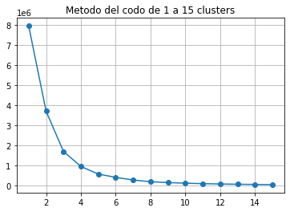

```python
from sklearn.cluster import KMeans
import matplotlib.pyplot as plt

sse=[]

clusters=list(range(1,16))
for k in clusters:
    kmeans = KMeans(n_clusters=k).fit(X)
    sse.append(kmeans.inertia_)

plt.plot(clusters, sse, marker="o")
plt.title("Metodo del codo de 1 a 15 clusters")
plt.grid(True)
plt.show()
```

Luego de realizar el método del codo, este nos indica que la cantidad optima de clusters a utilizar es 3.

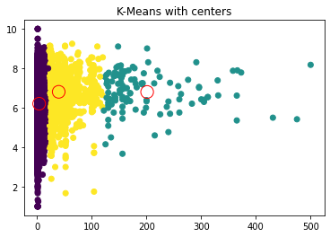

```python
kmeans = KMeans(n_clusters=3, random_state=50).fit(X)
centers = kmeans.cluster_centers_

plt.scatter(X[:, 0], X[:, 1], c=kmeans.labels_)
plt.scatter(centers[:,0], centers[:,1], s=200, facecolors='none', edgecolors='r')
plt.title("K-Means with centers")
plt.show()
```

Al fijarnos en el kmeans con 3 clusters, podemos ver claramente que dentro del rango 1-50 tenemos la mayor concentracion de animes, junto con los animes que mayor puntuacion poseen.

**Score y Duracion en minutos**

Lo siguiente que analizaremos, serán los grupos que se encuentran entre las variables "score" y "duration_minutes", para poder ver si existen grupos de animes que compartan un rango de duracion en minutos y posean una puntuación buena (score sobre 7).

```python
animeKmeans2.head()
```

|  | score | duration_minutes |
| --- | --- | --- |
| 0 | 7.63 | 24.0 |
| 1 | 7.89 | 24.0 |
| 2 | 7.55 | 24.0 |
| 3 | 8.21 | 16.0 |
| 4 | 8.67 | 24.0 |

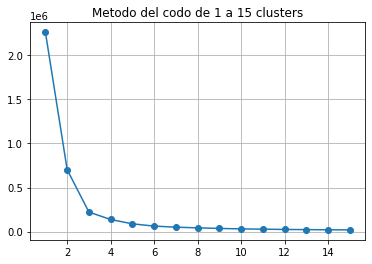

```python
from sklearn.cluster import KMeans
import matplotlib.pyplot as plt

sse=[]

clusters=list(range(1,16))
for k in clusters:
    kmeans = KMeans(n_clusters=k).fit(Y)
    sse.append(kmeans.inertia_)

plt.plot(clusters, sse, marker="o")
plt.title("Metodo del codo de 1 a 15 clusters")
plt.grid(True)
plt.show()
```

En este caso, tenemos una curva mas pareja y el numero de clusters que nos indica el metodo es 3.

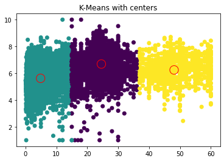

```python
kmeans = KMeans(n_clusters=3, random_state=50).fit(Y)
centers = kmeans.cluster_centers_

plt.scatter(Y[:, 1], Y[:, 0], c=kmeans.labels_)
plt.scatter(centers[:,1], centers[:,0], s=200, facecolors='none', edgecolors='r')
plt.title("K-Means with centers")
plt.show()
```

Obtenemos que el cluster con una concentracion de datos con mayor puntaje, se encuentra entre los valores 20 y 30 de la variable "duration_minutes", indicando que entre ese rango se encuentran generalmente los animes con mayor score.

### DBSCAN

Procederemos a utilizar otro algoritmo de clustering (dbscan) para comparar los resultados del K-Means.

**Score y Cantidad de Episodios**

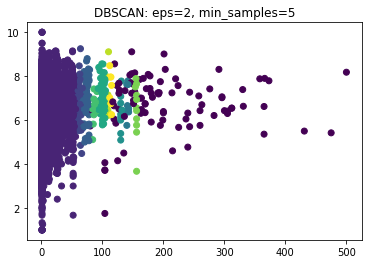

```python
from sklearn.cluster import DBSCAN
eps = 2       # Seleccionamos un eps de 1, que es la distancia dentro de la cual 2 puntos se consideran vecinos
min_samples = 5       # Seleccionamos un min_samples de 5 que es el numero de vecinos que tiene que tener un punto para ser considerado punto core

dbscan = DBSCAN(eps=eps, min_samples=min_samples).fit(X)
plt.scatter(X[:,0], X[:,1], c=dbscan.labels_)
plt.title(f"DBSCAN: eps={eps}, min_samples={min_samples}")
plt.show()
```

Podemos observar que DBSCAN nos identifica 3 clusters principales que se encuentran dentro del rango de 1 a 150 episodios y los demas puntos, los considera como ruido debido a que la distancia entre ellos y la cantidad de vecinos que poseen.

**Score y Duracion en Minutos**

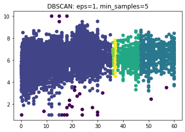

```python
from sklearn.cluster import DBSCAN
eps = 1
      # Seleccionamos un eps de 1, que es la distancia dentro de la cual 2 puntos se consideran vecinos
min_samples = 5  # Seleccionamos un min_samples de 5 para ver como DBSCAN grafica los resultados

dbscan = DBSCAN(eps=eps, min_samples=min_samples).fit(Y)
plt.scatter(Y[:,1], Y[:,0], c=dbscan.labels_)
plt.title(f"DBSCAN: eps={eps}, min_samples={min_samples}")
plt.show()
```

Podemos ver, que al colocar un min_samples bajo, DBSCAN no detecta los clusters de igual manera que con K-Means, probaremos utilizando un min_samples mas alto para que detecte a los grupos con mayor cantidad de vecinos

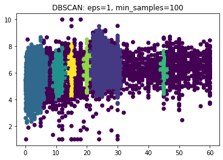

```python
from sklearn.cluster import DBSCAN
eps = 1
      # Seleccionamos un eps de 1, que es la distancia dentro de la cual 2 puntos se consideran vecinos
min_samples = 100  # Seleccionamos un min_samples de 100 para identificar los grupos con mayor cantidad de vecinos

dbscan = DBSCAN(eps=eps, min_samples=min_samples).fit(Y)
plt.scatter(Y[:,1], Y[:,0], c=dbscan.labels_)
plt.title(f"DBSCAN: eps={eps}, min_samples={min_samples}")
plt.show()
```

En este caso, aumentamos el min_samples a 100, para identificar claramente las agrupaciones que mayor cantidad de datos poseen, y podemos ver, que dentro del rango 20-30, se encuentra uno de los clusters con mayor cantidad de datos y como obtuvimos previamente con K-Means, mayor puntuacion o score.

### Evaluacion de Clusters

Como mencionamos previamente, aparte del enfoque visual, utilizaremos la Matriz de similitud para evaluar nuestros clusters.

```python
from sklearn.metrics.pairwise import euclidean_distances
```

```python
def sim_matrix(features, labels):
    useful_labels = labels >= 0

    # primero ordenamos los datos en base al cluster que pertencen
    indices = np.argsort(labels[useful_labels])
    sorted_features = features[useful_labels][indices]

    # calculamos las distancias entre todos los puntos
    d = euclidean_distances(sorted_features, sorted_features)
    return d

def plot(data, model):
    fig, (ax1, ax2) = plt.subplots(1, 2, figsize=(20,5))

    fig.suptitle(f"{model.__class__.__name__}")

    ax1.scatter(data[:,0], data[:,1], c=model.labels_)

    dist = sim_matrix(data, model.labels_)
    im = ax2.imshow(dist, cmap="jet")
    fig.colorbar(im, ax=ax2)
```

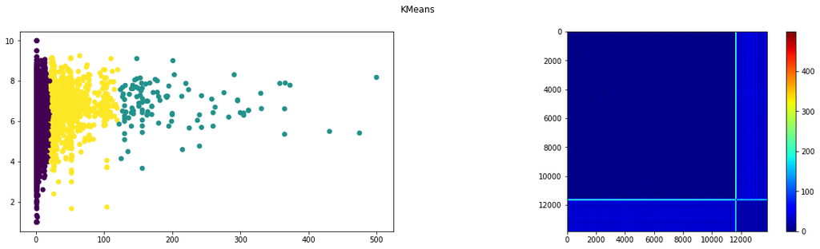

```python
kmeans1 = KMeans(n_clusters=3, random_state=50).fit(X)
plot(X, kmeans1)
plt.show()
```

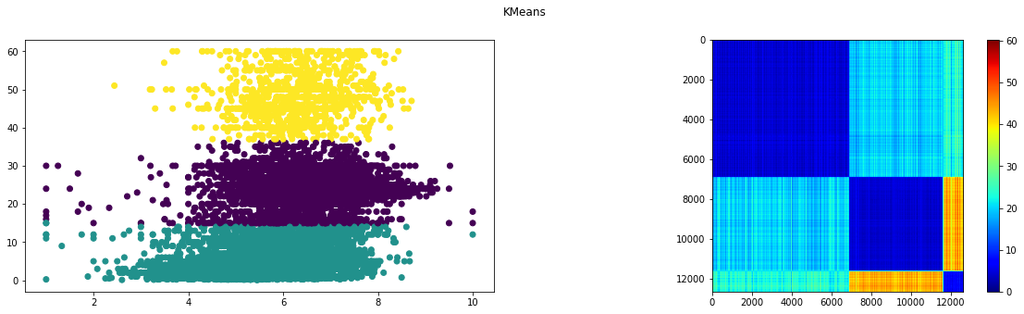

```python
kmeans2 = KMeans(n_clusters=3, random_state=50).fit(Y)
plot(Y, kmeans2)
plt.show()
```

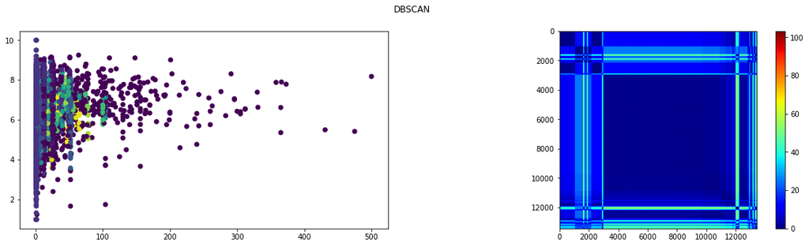

```python
dbscan1 = DBSCAN(eps=0.5, min_samples=5).fit(X)
plot(X, dbscan1)
plt.show()
```

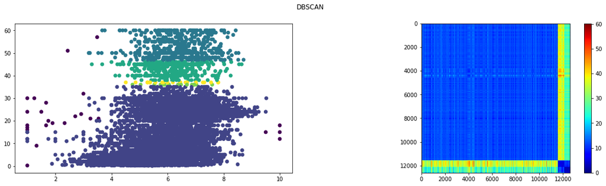

```python
dbscan2 = DBSCAN(eps=1, min_samples=5).fit(Y)
plot(Y, dbscan2)
plt.show()
```

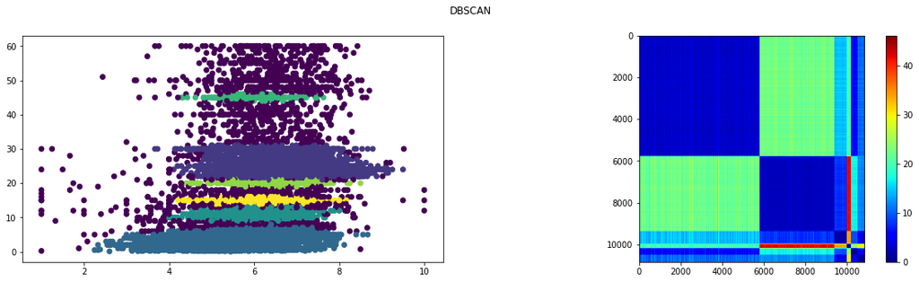

```python
dbscan2 = DBSCAN(eps=1, min_samples=100).fit(Y)
plot(Y, dbscan2)
plt.show()
```

De las pruebas podemos concluir que K-Means capturó de mejor manera los 3 clusters que habiamos definido previamente.

### Conclusion propuesta experimental 2

Luego de realizar los metodos de clustering con los datos, y enfocarnos en la cantidad de episodios junto con la duracion en minutos de los animes, podemos obtener que los animes que serian ideales y de mayor utilidad para el estudio de televisión que nos contrato, serian aquellos animes que cuenten con una cantidad de episodios dentro del rango 1-50 y de una duracion en minutos de 20-30 por episodio.

# **Contribuciones**

- Andy Sandoval: Problemática 1
- Christopher Álarcon: Problemática 2